# DATA70121CourseworkAssignment

### Q1: Description of the Data

The data used in this report comes from Maven Analytics, an organization that provides training in data science. This data set contains information about simulated train journeys within the UK, capturing details such as train schedules, ticket sales (in pounds), passenger demographics, and operational performance. It contains information about more than 31,000 journeys.

### Q2: Exploratory Data Analysis

The data set has very few missing values. It appears that there are 1,880 missing Actual Arrivals.

```
##    Payment.Method          Railcard      Ticket.Class       Ticket.Type
##                 0                 0                 0                 0
##             Price Departure.Station   Arrival.Station         Departure
##                 0                 0                 0                 3
## Scheduled.Arrival    Actual.Arrival    Journey.Status  Reason.for.Delay
##                 4              1880                 0                 0
##    Refund.Request    refund_encoded
##                 0                 0
```

```
##    Payment.Method          Railcard      Ticket.Class       Ticket.Type
##                 0                 0                 0                 0
##             Price Departure.Station   Arrival.Station         Departure
##                 0                 0                 0                 3
## Scheduled.Arrival    Actual.Arrival    Journey.Status  Reason.for.Delay
##                 4                 3                 0                 0
##    Refund.Request    refund_encoded
##                 0                 0
```

After filtering, there is still 3 missing values in Actual.Arrival and Departure and 4 missing values in Scheduled.Arrival. However, with a dataset of over 31,000 three values will not have a large impact on the final statistical analysis. If these missing values become an issue later, the rows can be excluded from analysis. Because they represent times, it would be difficult to replace with a summary statistic such as a mean, so they would have to be removed.

Now that it has been established the data is mostly complete, it is possible to visualise which variables have the greatest impact on refund requests.

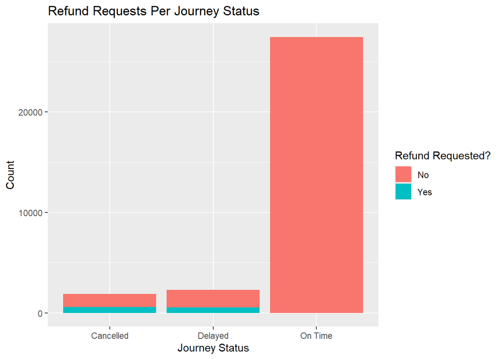

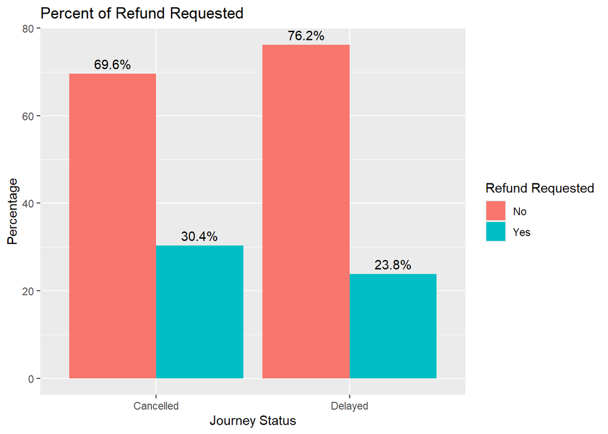

30.4% of journeys that are cancelled recieve refund requests, while only 23.8% of delayed journeys do. While there isn’t a massive difference, this will be good to keep in mind when creating a model.

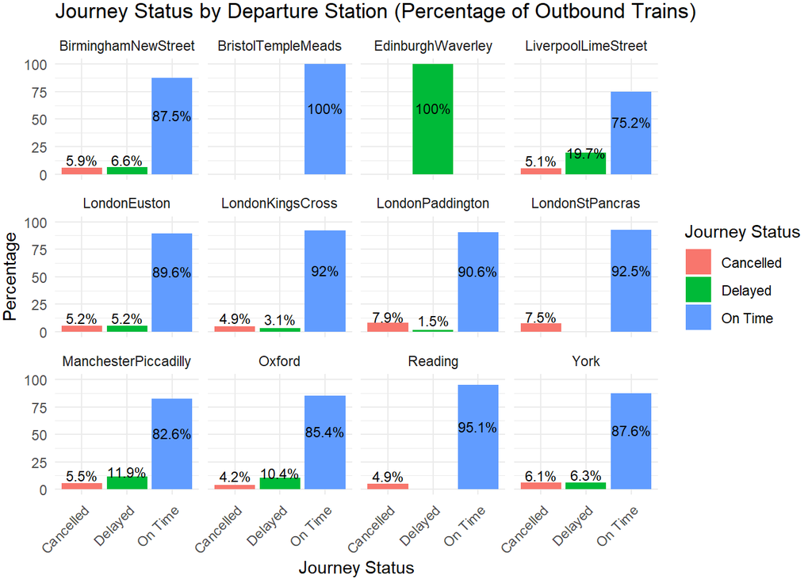

This analysis reveals that most stations have trains that depart on time approximately 90% of the time. The notable exception is Edinburgh Waverley, where 100% of departing trains were delayed. Given that prior analysis has shown a higher likelihood of refund requests for cancelled and delayed trains, and considering that delay and cancellation rates vary by station, the departure station may be a significant predictor in the regression model.

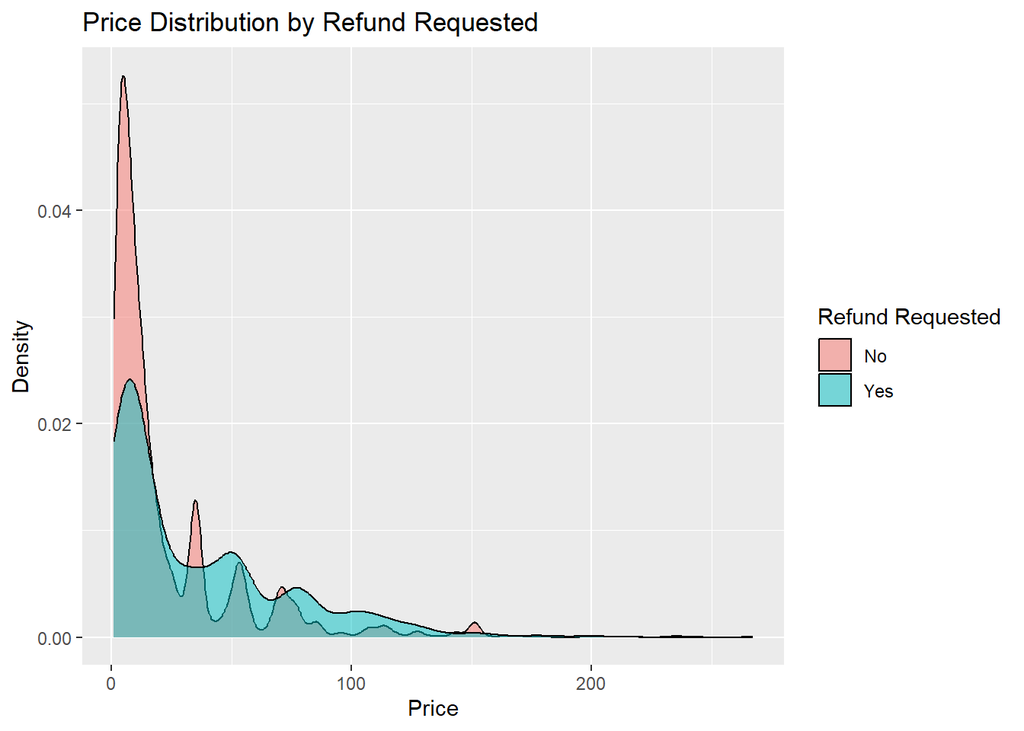

| Refund.Request | AveragePrice |
| --- | --- |
| No | 23.03013 |
| Yes | 34.52065 |

However, by looking at the average price of a refund request ticket compared to one where no refund was requested, we can see that the average price is higher if a refund was requested.

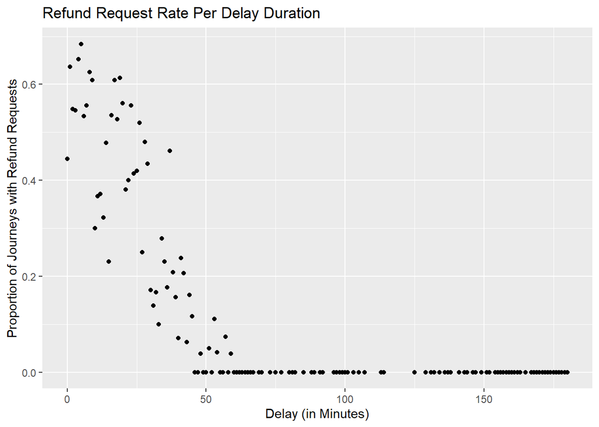

There does appear to be a correlation between the proportion of refund requests and length of a delay. When delay increases, it appears that the proportion of customers requesting a refund decreases.

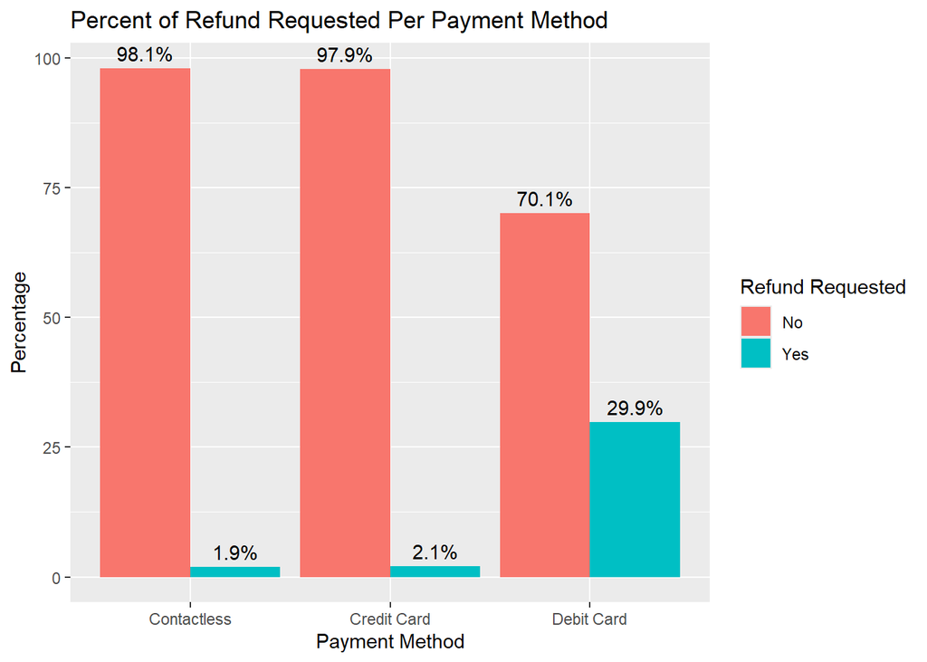

Of people who used the varying payment methods, it appears tickets paid for with a debit card receive significantly more refund requests than journeys paid for with contactless or credit card.

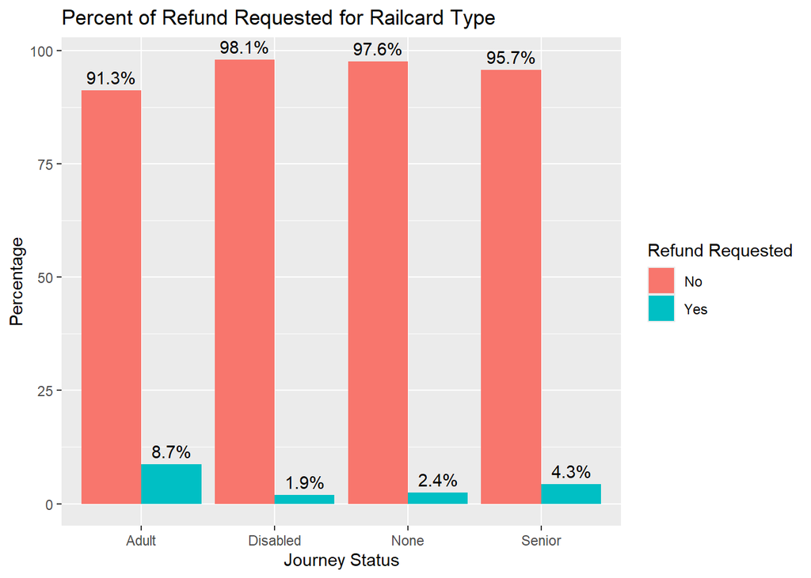

There does appear to be some difference in the rates railcard users request refunds. Adults using a railcard are twice as likely to request a refund as the next most likely railcard holder category (Senior). Railcard usage could be a factor in the regression model.

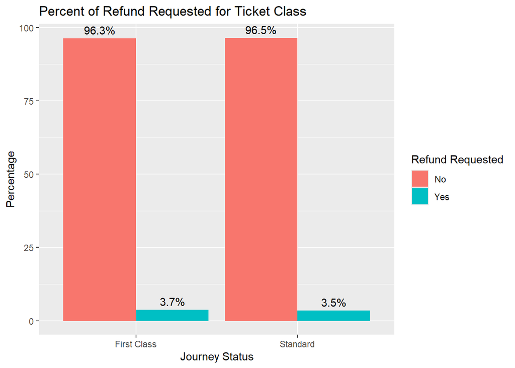

The rates for refund requests between first class and standard are roughly the same, so this most likely does not impact whether a person will request a refund or not.

### Q3: Add DelayInMinutes Column

```r
# If Journey Status is "Delayed", then add total delay in minutes by subtracting Scheduled and Actual, if FALSE, insert NA
data <- data %>%
  mutate(DelayInMinutes = ifelse(Journey.Status == "Delayed", as.numeric(difftime(Actual.Arrival, Scheduled.Arrival, units="mins")), NA))
head(data)
```

|  | Payment.Method | Railcard | Ticket.Class | Ticket.Type | Price | Departure.Station | Arrival.Station | Departure | Scheduled.Arrival | Actual.Arrival | Journey.Status | Reason.for.Delay | Refund.Request | refund_encoded | DelayInMinutes |
| --- | --- | --- | --- | --- | --- | --- | --- | --- | --- | --- | --- | --- | --- | --- | --- |
| 1 | Contactless | Adult | Standard | Advance | 43 | LondonPaddington | Liverpool Lime Street | 2024-01-01 11:00:00 | 2024-01-01 13:30:00 | 2024-01-01 13:30:00 | On Time |  | No | 0 | NA |
| 2 | Credit Card | Adult | Standard | Advance | 23 | LondonKingsCross | York | 2024-01-01 09:45:00 | 2024-01-01 11:35:00 | 2024-01-01 11:40:00 | Delayed | Signal Failure | No | 0 | 5 |
| 3 | Credit Card | None | Standard | Advance | 3 | LiverpoolLimeStreet | Manchester Piccadilly | 2024-01-02 18:15:00 | 2024-01-02 18:45:00 | 2024-01-02 18:45:00 | On Time |  | No | 0 | NA |
| 4 | Credit Card | None | Standard | Advance | 13 | LondonPaddington | Reading | 2024-01-01 21:30:00 | 2024-01-01 22:30:00 | 2024-01-01 22:30:00 | On Time |  | No | 0 | NA |
| 5 | Contactless | None | Standard | Advance | 76 | LiverpoolLimeStreet | London Euston | 2024-01-01 16:45:00 | 2024-01-01 19:00:00 | 2024-01-01 19:00:00 | On Time |  | No | 0 | NA |
| 6 | Credit Card | None | Standard | Advance | 35 | LondonKingsCross | York | 2024-01-01 06:15:00 | 2024-01-01 08:05:00 | 2024-01-01 08:05:00 | On Time |  | No | 0 | NA |

### Q4:Use Regression to Predit Probability of Refund Request

I filtered the data set to only include not on time journeys and created a MediumPrice column

|  | Payment.Method | Railcard | Ticket.Class | Ticket.Type | Price | Departure.Station | Arrival.Station | Departure | Scheduled.Arrival | Actual.Arrival | Journey.Status | Reason.for.Delay | Refund.Request | refund_encoded | DelayInMinutes | MediumPrice |
| --- | --- | --- | --- | --- | --- | --- | --- | --- | --- | --- | --- | --- | --- | --- | --- | --- |
| 1 | Credit Card | Adult | Standard | Advance | 23 | LondonKingsCross | York | 2024-01-01 09:45:00 | 2024-01-01 11:35:00 | 2024-01-01 11:40:00 | Delayed | Signal Failure | No | 0 | 5 | TRUE |
| 2 | Credit Card | None | Standard | Advance | 37 | LondonEuston | York | 2024-01-01 00:00:00 | 2024-01-01 01:50:00 | 2024-01-01 02:07:00 | Delayed | Signal Failure | No | 0 | 17 | FALSE |
| 3 | Debit Card | Adult | Standard | Advance | 7 | BirminghamNewStreet | Manchester Piccadilly | 2024-01-01 11:15:00 | 2024-01-01 12:35:00 | 2024-01-01 13:06:00 | Delayed | Technical Issue | Yes | 1 | 31 | FALSE |
| 4 | Credit Card | Senior | First Class | Advance | 34 | Oxford | Bristol Temple Meads | 2024-01-01 14:15:00 | 2024-01-01 15:30:00 | 2024-01-01 15:54:00 | Delayed | Signal Failure | Yes | 1 | 24 | FALSE |
| 5 | Credit Card | None | Standard | Advance | 7 | LondonEuston | Birmingham New Street | 2024-01-02 02:15:00 | 2024-01-02 03:35:00 |  | Cancelled | Technical Issue | No | 0 | NA | FALSE |
| 6 | Credit Card | None | First Class | Advance | 134 | ManchesterPiccadilly | London Euston | 2024-01-02 03:30:00 | 2024-01-02 05:20:00 | 2024-01-02 05:31:00 | Delayed | Weather | No | 0 | 11 | FALSE |

I fit a logistic regression model, as it will return the probability of an event, not the correlation as a linear regression would

```
##
## Call:
## glm(formula = refund_encoded ~ MediumPrice, family = "binomial",
##     data = NotOnTime)
##
## Coefficients:
##                 Estimate Std. Error z value Pr(>|z|)
## (Intercept)     -1.07572    0.03928 -27.383  < 2e-16 ***
## MediumPriceTRUE  0.35440    0.08723   4.063 4.85e-05 ***
## ---
## Signif. codes:  0 '***' 0.001 '**' 0.01 '*' 0.05 '.' 0.1 ' ' 1
##
## (Dispersion parameter for binomial family taken to be 1)
##
##     Null deviance: 4838  on 4165  degrees of freedom
## Residual deviance: 4822  on 4164  degrees of freedom
## AIC: 4826
##
## Number of Fisher Scoring iterations: 4
```

Then, using the equation from the Week 5 lecture notes:
$$\log\left(\frac{p_i}{1 - p_i}\right) = \beta_0 + \beta_1 \cdot
MediumPrice$$
Plug in the information from the regression, where $\beta_0 = -1.07572$ and $\beta_1 = 0.35440$. Because £5 does not fall within the £10 < Price < £30 range given for MediumPrice, 0 is used in the equation.

$$\log\left(\frac{p_i}{1 - p_i}\right) = -1.07572 + 0.35440 \cdot 0
\newline
\frac{p_i}{1 - p_i}\ = e^{-1.07572}
\newline
p_i = e^{-1.07572} - e^{-1.07572} \cdot p_i
\newline
1.341 \cdot p_i= 0.341
\newline
p_i= 0.254$$
Given a passenger paid £5 for their ticket, there is a 0.254 probability they will request a refund.

This time, because £25 does fall within the £10 < Price < £30 range given for MediumPrice, 1 is used in the equation.
$$\log\left(\frac{p_i}{1 - p_i}\right) = -1.07572 + (0.35440 \cdot 1)
\newline
\frac{p_i}{1 - p_i}\ = e^{-0.72132}
\newline
p_i = e^{-0.72132} - e^{-0.72132} \cdot p_i
\newline
1.486 \cdot p_i= 0.486
\newline
p_i= 0.327$$
Given a passenger paid £25 for their ticket, there is a 0.327 probability they will request a refund.

### Q5: Regression Model to Predict Refund

I began by splitting the data into test (20%) and training (80%).

I started with a very simple model: status_model, that only took into account the Journey.Status, since On Time trains don’t receive refund requests.

```
##
## Call:
## glm(formula = refund_encoded ~ Journey.Status, family = "binomial",
##     data = train_data)
##
## Coefficients:
##                        Estimate Std. Error z value Pr(>|z|)
## (Intercept)            -0.84346    0.05657 -14.911  < 2e-16 ***
## Journey.StatusDelayed  -0.31052    0.07846  -3.958 7.56e-05 ***
## Journey.StatusOn Time -20.72261  197.20163  -0.105    0.916
## ---
## Signif. codes:  0 '***' 0.001 '**' 0.01 '*' 0.05 '.' 0.1 ' ' 1
##
## (Dispersion parameter for binomial family taken to be 1)
##
##     Null deviance: 7721.0  on 25315  degrees of freedom
## Residual deviance: 3862.1  on 25313  degrees of freedom
## AIC: 3868.1
##
## Number of Fisher Scoring iterations: 20
```

Because Edinburgh Waverly’s delay rate was so high, I was interested in seeing what impact departure station had on the model in addition to the Journey Status, so I fit the model departure_station_model

```
##
## Call:
## glm(formula = refund_encoded ~ Journey.Status + Departure.Station,
##     family = "binomial", data = train_data)
##
## Coefficients:
##                                         Estimate Std. Error z value Pr(>|z|)
## (Intercept)                              0.60057    0.15115   3.973 7.09e-05
## Journey.StatusDelayed                   -0.59008    0.09557  -6.174 6.65e-10
## Journey.StatusOn Time                  -20.99774  190.86420  -0.110   0.9124
## Departure.StationBristolTempleMeads     -1.16890 8109.86584   0.000   0.9999
## Departure.StationEdinburghWaverley      21.55557 4357.71452   0.005   0.9961
## Departure.StationLiverpoolLimeStreet    -1.15865    0.16221  -7.143 9.15e-13
## Departure.StationLondonEuston           -1.69868    0.18883  -8.996  < 2e-16
## Departure.StationLondonKingsCross       -1.58264    0.20687  -7.650 2.00e-14
## Departure.StationLondonPaddington       -1.68872    0.19536  -8.644  < 2e-16
## Departure.StationLondonStPancras        -1.75802    0.21620  -8.131 4.24e-16
## Departure.StationManchesterPiccadilly   -1.59158    0.16841  -9.451  < 2e-16
## Departure.StationOxford                  2.60798    1.04422   2.498   0.0125
## Departure.StationReading                -0.26410    0.44077  -0.599   0.5491
## Departure.StationYork                   -1.98675    0.30990  -6.411 1.45e-10
##
## (Intercept)                           ***
## Journey.StatusDelayed                 ***
## Journey.StatusOn Time
## Departure.StationBristolTempleMeads
## Departure.StationEdinburghWaverley
## Departure.StationLiverpoolLimeStreet  ***
## Departure.StationLondonEuston         ***
## Departure.StationLondonKingsCross     ***
## Departure.StationLondonPaddington     ***
## Departure.StationLondonStPancras      ***
## Departure.StationManchesterPiccadilly ***
## Departure.StationOxford               *
## Departure.StationReading
## Departure.StationYork                 ***
## ---
## Signif. codes:  0 '***' 0.001 '**' 0.01 '*' 0.05 '.' 0.1 ' ' 1
##
## (Dispersion parameter for binomial family taken to be 1)
##
##     Null deviance: 7721.0  on 25315  degrees of freedom
## Residual deviance: 3554.6  on 25302  degrees of freedom
## AIC: 3582.6
##
## Number of Fisher Scoring iterations: 20
```

I also fit a model that included Journey.Status, Price, Railcard, and Payment.Method as those seemed to have the strongest correlation exhibited during EDA. To simplify the process, instead of encoding the railcard variable, I created a new column: Railcard.Owner, that was 1 if the passenger had any railcard and 0 if they had none. This was called price_model.

```
##
## Call:
## glm(formula = refund_encoded ~ Journey.Status + Price + Railcard.Owner +
##     Payment.Method, family = "binomial", data = train_data)
##
## Coefficients:
##                             Estimate Std. Error z value Pr(>|z|)
## (Intercept)               -8.896e-01  1.069e-01  -8.324  < 2e-16 ***
## Journey.StatusDelayed     -1.608e+00  1.252e-01 -12.846  < 2e-16 ***
## Journey.StatusOn Time     -2.232e+01  3.045e+02  -0.073  0.94159
## Price                      4.316e-04  1.277e-03   0.338  0.73544
## Railcard.Owner             2.842e-01  1.056e-01   2.693  0.00709 **
## Payment.MethodCredit Card -2.665e-01  1.130e-01  -2.359  0.01831 *
## Payment.MethodDebit Card   3.271e+00  1.682e-01  19.441  < 2e-16 ***
## ---
## Signif. codes:  0 '***' 0.001 '**' 0.01 '*' 0.05 '.' 0.1 ' ' 1
##
## (Dispersion parameter for binomial family taken to be 1)
##
##     Null deviance: 7721.0  on 25315  degrees of freedom
## Residual deviance: 2944.5  on 25309  degrees of freedom
## AIC: 2958.5
##
## Number of Fisher Scoring iterations: 21
```

Finally, I wanted another simple model, so I fit one that only incorporated Journey.Status and Price

```
##
## Call:
## glm(formula = refund_encoded ~ Journey.Status + Price, family = "binomial",
##     data = train_data)
##
## Coefficients:
##                         Estimate Std. Error z value Pr(>|z|)
## (Intercept)           -7.556e-01  6.034e-02 -12.523  < 2e-16 ***
## Journey.StatusDelayed -1.938e-01  8.300e-02  -2.335   0.0196 *
## Journey.StatusOn Time -2.073e+01  1.971e+02  -0.105   0.9162
## Price                 -3.829e-03  9.382e-04  -4.081 4.49e-05 ***
## ---
## Signif. codes:  0 '***' 0.001 '**' 0.01 '*' 0.05 '.' 0.1 ' ' 1
##
## (Dispersion parameter for binomial family taken to be 1)
##
##     Null deviance: 7721.0  on 25315  degrees of freedom
## Residual deviance: 3844.7  on 25312  degrees of freedom
## AIC: 3852.7
##
## Number of Fisher Scoring iterations: 20
```

I considered including a DelayInMinutes predictor in the model but ultimately decided against it. The main challenge was that it was difficult to accurately distinguish whether missing values for DelayInMinutes were due to no delay or because the train was cancelled. Instead, I opted to use the Journey.Status predictor, as it effectively captures the impact of delays and cancellations on the likelihood of a refund request.

```
## Status Model Accuracy:
```

```
## Matches: 6107 Percentage: 96.49234 %
```

```
## Departure Station Model Accuracy:
```

```
## Matches: 6126 Percentage: 96.79254 %
```

```
## Price Model Accuracy:
```

```
## Matches: 6185 Percentage: 97.72476 %
```

```
## Simple Model Accuracy:
```

```
## Matches: 6107 Percentage: 96.49234 %
```

| Model | TP | FP | TN | FN |
| --- | --- | --- | --- | --- |
| Status Model | 0 | 0 | 6107 | 222 |
| Departure Station Model | 48 | 29 | 6078 | 174 |
| Price Model | 99 | 21 | 6086 | 123 |
| Simple Model | 0 | 0 | 6107 | 222 |

|  | Payment.Method | Railcard | Ticket.Class | Ticket.Type | Price | Departure.Station | Arrival.Station | Departure | Scheduled.Arrival | Actual.Arrival | Journey.Status | Reason.for.Delay | Railcard.Owner | predicted_refund |
| --- | --- | --- | --- | --- | --- | --- | --- | --- | --- | --- | --- | --- | --- | --- |
| 1 | Debit Card | None | First Class | Advance | 54 | London St Pancras | Birmingham New Street | 2024-01-04 17:45 | 2024-01-04 19:05 | 2024-01-04 19:05 | On Time |  | 0 | 0 |
| 2 | Credit Card | None | Standard | Advance | 7 | London Euston | Birmingham New Street | 2024-01-05 08:15 | 2024-01-05 09:35 | 2024-01-05 09:35 | On Time |  | 0 | 0 |
| 3 | Debit Card | None | Standard | Off-Peak | 113 | Liverpool Lime Street | London Euston | 2024-01-09 15:30 | 2024-01-09 17:45 | 2024-01-09 18:07 | Delayed | Staffing | 0 | 1 |
| 4 | Contactless | Adult | Standard | Off-Peak | 3 | Liverpool Lime Street | Manchester Piccadilly | 2024-01-31 05:45 | 2024-01-31 06:15 | 2024-01-31 06:49 | Delayed | Signal Failure | 1 | 0 |
| 5 | Credit Card | None | Standard | Off-Peak | 4 | Manchester Piccadilly | Liverpool Lime Street | 2024-02-10 16:00 | 2024-02-10 16:30 | NA | Cancelled | Technical Issue | 0 | 0 |
| 6 | Contactless | None | Standard | Advance | 3 | Manchester Piccadilly | Liverpool Lime Street | 2024-02-25 15:45 | 2024-02-25 16:15 | NA | Cancelled | Staffing | 0 | 0 |

### References

Confusion matrix: https://www.digitalocean.com/community/tutorials/confusion-matrix-in-r

Week 5 Lecture Notes

GGPlot Bar Plot: https://r-graph-gallery.com/48-grouped-barplot-with-ggplot2

## Data Set Up

```r
#Load packages
library(fastDummies)
library(dplyr)
library(readr)
library(lubridate)
library(ggplot2)
library(caret)
```

```r
#Read CSV
data <-read.csv("MavenRail.csv")

#Change date to POSIXct type
data$Departure <- as.POSIXct( data$Departure, format="%Y-%m-%d %H:%M" )
data$Scheduled.Arrival <- as.POSIXct( data$Scheduled.Arrival, format="%Y-%m-%d %H:%M" )
data$Actual.Arrival <- as.POSIXct( data$Actual.Arrival, format="%Y-%m-%d %H:%M" )
sapply(data, class)

#Remove spaces from strings in columns so dummy variable encoding can be done later one (code from: https://stackoverflow.com/questions/20760547/removing-whitespace-from-a-whole-data-frame-in-r)
data <- data %>%
  mutate(Departure.Station = gsub('\\s+', '', Departure.Station))

# Add another column where it encodes Refund.Request where Yes = 1 and No = 0 to make regression easier
data <- data %>%
  mutate(refund_encoded = ifelse(data$Refund.Request == "Yes", 1, 0))

NotOnTime <- filter(data, Journey.Status != "On Time")
```

## Q2

```r
#Missing data
#Sum rows in each column where the value is NA and return the dataframe
missing <- colSums(is.na(data))
missing
```

```r
#Missing data with cancelled journeys removed
#Remove cancelled journeys and repeat
filt <- filter(data, Journey.Status !="Cancelled")
cancelled_missing <- colSums(is.na(filt))
cancelled_missing
```

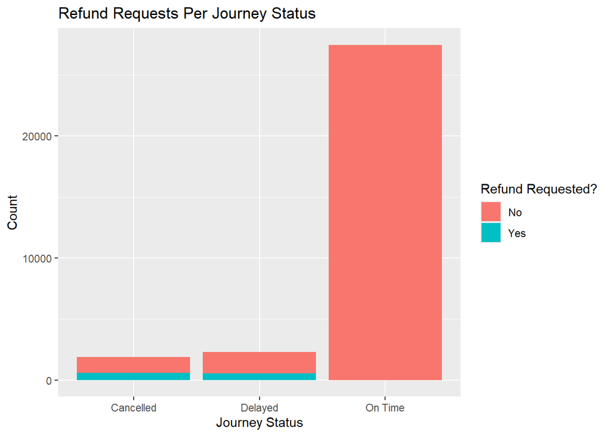

```r
#Refund Requests Per Journey Status Chart
#Establish relationship between delayed/cancelled and refund
bar_filt <- filter(data)
ggplot(bar_filt, aes(x=Journey.Status, fill=Refund.Request)) +
  geom_bar() +
  labs(
    title = "Refund Requests Per Journey Status",
    x = "Journey Status",
    y = "Count"
  ) +
  scale_fill_discrete(name = "Refund Requested?")
```

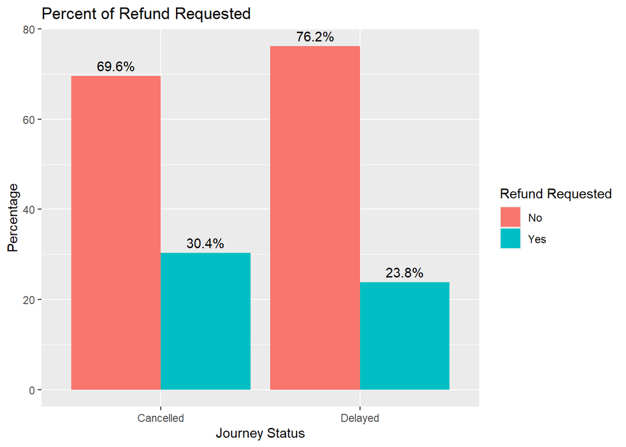

```r
#Percent of cancelled and delayed journeys with a refund request chart

refund_data <- data %>%
  filter(Journey.Status != "On Time") %>%
  # Filter for Cancelled and Delayed only
  group_by(Journey.Status, Refund.Request) %>%
  summarize(count = n(), .groups = "drop") %>%
  # Calculate the total count for each Journey.Status
  group_by(Journey.Status) %>%
  mutate(total_count = sum(count)) %>%
  ungroup() %>%
  # Calculate the percentage of refund requests within each Journey.Status
  mutate(percentage = (count / total_count) * 100)

# Create chart
ggplot(refund_data, aes(x = Journey.Status, y = percentage, fill = Refund.Request)) +
  geom_bar(stat = "identity", position="dodge") +
 geom_text(aes(label = paste0(round(percentage, 1), "%")),  # Add percentage labels
            position = position_dodge(width = 0.9), vjust = -0.5, color = "black") +  # Adjust text position above bars
  labs(
    title = "Percent of Refund Requested",
    x = "Journey Status",
    y = "Percentage",
    fill = "Refund Requested"
  )
```

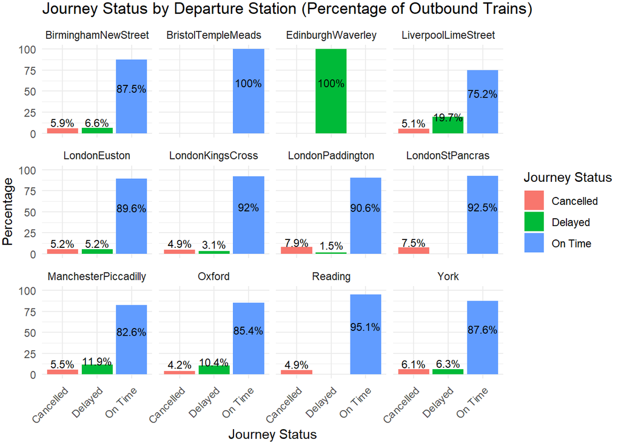

```r
#Delayed, cancelled, and on time trains departing from each station

#Mutate data in pipeline so we have data about which percentage of trains are on time, cancelled, and delayed from each station
percentage_data <- data %>%
  #Group by departure station and journey status
  group_by(Departure.Station, Journey.Status) %>%
  #Count how many journeys are listed as each status and departure station, then ungroup
  summarize(Count = n(), .groups = "drop") %>%
  group_by(Departure.Station) %>%
  #Group by departure station and calculate which the percentage of trains that were on time, delayed, or cancelled
  mutate(Percentage = Count / sum(Count) * 100)

#Create a bar chart that shows the percentage of trains on time, delayed, or cancelled at each departure station
ggplot(percentage_data, aes(x = Journey.Status, y = Percentage, fill = Journey.Status)) +
  geom_bar(stat = "identity") +
  # Split into panels by departure station
  facet_wrap(~ Departure.Station) +
  geom_text(aes(label = paste0(round(Percentage, 1), "%")), position = position_stack(vjust = 0.5), size = 3, vjust= -0.5) +
  labs(
    title = "Journey Status by Departure Station (Percentage of Outbound Trains)",
    x = "Journey Status",
    y = "Percentage",
    fill = "Journey Status"
  ) +
  theme_minimal() +
  theme(
    axis.text.x = element_text(angle = 45, hjust = 1),
    plot.margin = margin(.05, .05, .05, .05, "cm")
  )
```

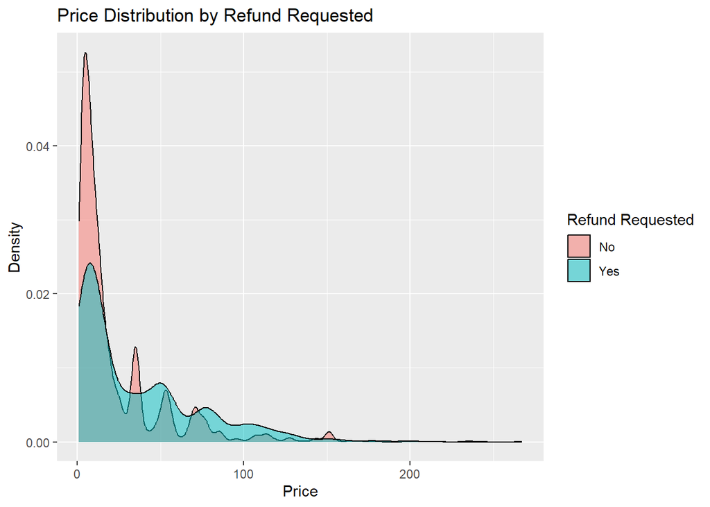

```r
#Price density graph
ggplot(data, aes(x = Price, fill = Refund.Request)) +
  geom_density(alpha = 0.5) +
  labs(
    title = "Price Distribution by Refund Requested",
    x = "Price",
    y = "Density",
    fill = "Refund Requested"
  )
```

```r
#Table with average price of a refund requested ticket vs not

data %>%
  group_by(Refund.Request) %>%
  summarise(
    AveragePrice = mean(Price)
  )
```

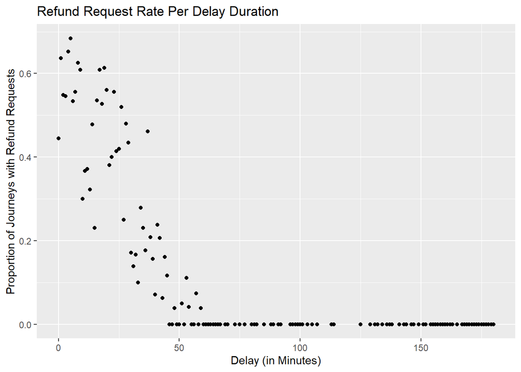

```r
#Scatterplot proprotion of refund requests per delay duration
data <- data %>%
  mutate(DelayInMinutes = ifelse(Journey.Status == "Delayed", as.numeric(difftime(Actual.Arrival, Scheduled.Arrival, units="mins")), NA))

delay_binned_data <- data %>%
  filter(Journey.Status == "Delayed") %>%
  group_by(DelayInMinutes) %>%
  summarize(
    delay_total = n(),  # Total journeys for each price
    bin_ref_tot = sum(refund_encoded, na.rm = TRUE),  # Total refunds in each price group
    bin_prop = bin_ref_tot / delay_total
  )

ggplot(delay_binned_data, aes(x = DelayInMinutes, y = bin_prop)) +
  geom_point() +
  labs (
    title = "Refund Request Rate Per Delay Duration",
    x = "Delay (in Minutes)",
    y = "Proportion of Journeys with Refund Requests"
  )
```

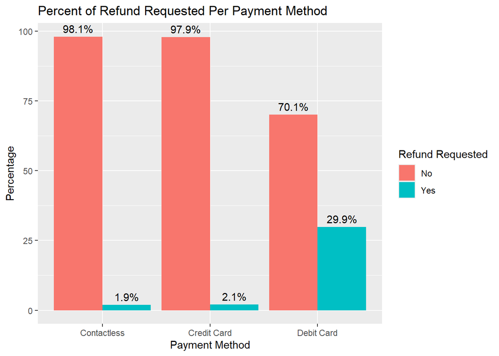

```r
#Percent of Refund Requested per payment method
pay_data <- data %>%
  group_by(Payment.Method, Refund.Request) %>%
  summarize(count = n(), .groups = "drop") %>%
  # Calculate the total count for each payment method
  group_by(Payment.Method) %>%
  mutate(total_count = sum(count)) %>%
  ungroup() %>%
  # Calculate the percentage of refund requests within each method
  mutate(percentage = (count / total_count) * 100)

ggplot(pay_data, aes(x = Payment.Method, y = percentage, fill = Refund.Request)) +
  geom_bar(stat = "identity", position="dodge") +  # Create bars with the percentage value
 geom_text(aes(label = paste0(round(percentage, 1), "%")),  # Add percentage labels
            position = position_dodge(width = 0.9), vjust = -0.5, color = "black") +  # Adjust text position above bars
  labs(
    title = "Percent of Refund Requested Per Payment Method",
    x = "Payment Method",
    y = "Percentage",
    fill = "Refund Requested"
  )
```

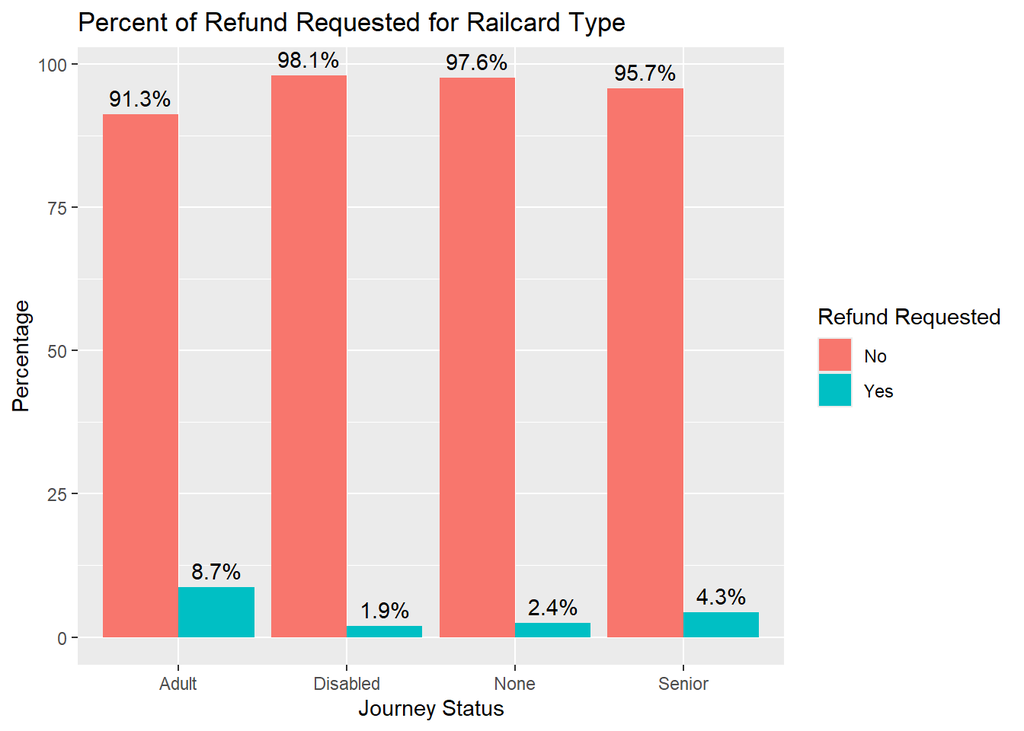

```r
#Percent of Refund Requested for Railcard Type
card_data <- data %>%
  group_by(Railcard, Refund.Request) %>%
  summarize(count = n(), .groups = "drop") %>%
  group_by(Railcard) %>%
  mutate(total_count = sum(count)) %>%
  ungroup() %>%
  mutate(percentage = (count / total_count) * 100)

ggplot(card_data, aes(x = Railcard, y = percentage, fill = Refund.Request)) +
  geom_bar(stat = "identity", position="dodge") +
  geom_text(aes(label = paste0(round(percentage, 1), "%")),
            position = position_dodge(width = 0.9), vjust = -0.5, color = "black") +
  labs(
    title = "Percent of Refund Requested for Railcard Type",
    x = "Journey Status",
    y = "Percentage",
    fill = "Refund Requested"
  )
```

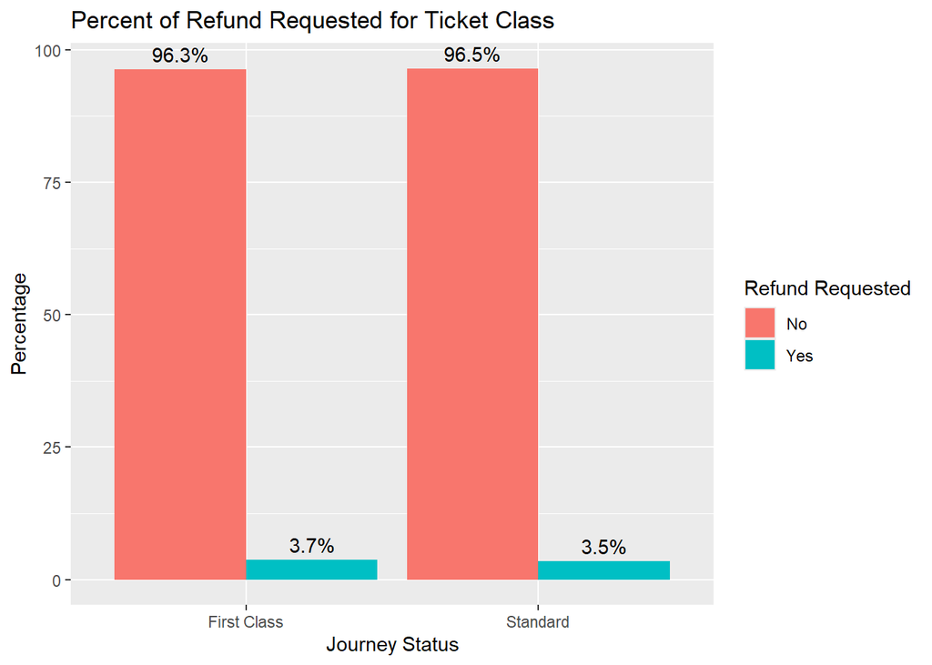

```r
#Percent refund requests per ticket class
class_data <- data %>%
  group_by(Ticket.Class, Refund.Request) %>%
  summarize(count = n(), .groups = "drop") %>%
  group_by(Ticket.Class) %>%
  mutate(total_count = sum(count)) %>%
  ungroup() %>%
  mutate(percentage = (count / total_count) * 100)

ggplot(class_data, aes(x = Ticket.Class, y = percentage, fill = Refund.Request)) +
  geom_bar(stat = "identity", position="dodge") +
  geom_text(aes(label = paste0(round(percentage, 1), "%")),
            position = position_dodge(width = 0.9), vjust = -0.5, color = "black") +
  labs(
    title = "Percent of Refund Requested for Ticket Class",
    x = "Journey Status",
    y = "Percentage",
    fill = "Refund Requested"
  )
```

## Q3

```r
# If Journey Status is "Delayed", then add total delay in minutes by subtracting Scheduled and Actual, if FALSE, insert NA
data <- data %>%
  mutate(DelayInMinutes = ifelse(Journey.Status == "Delayed", as.numeric(difftime(Actual.Arrival, Scheduled.Arrival, units="mins")), NA))
head(data)
```

## Q4

```r
# Select all journeys where Journey Status is not "On Time" and put it in its own data frame
NotOnTime <- filter(data, Journey.Status != "On Time")

# If the price is between 30 and 10, insert TRUE in a new column "MediumPrice", if not insert FALSE
NotOnTime <- NotOnTime %>%
  mutate(MediumPrice = ifelse(30 >= NotOnTime$Price & NotOnTime$Price > 10, TRUE, FALSE))
head(NotOnTime)
```

```r
#Create a logistic regression model
refund = glm(refund_encoded ~ MediumPrice, data= NotOnTime, family= "binomial")
summary(refund)
```

## Q5

```r
#Add column railcard owner
#Split data test and train, setting seed so split is the same each time
data <- data %>%
  mutate(Railcard.Owner = ifelse(Railcard != "None", 1, 0))

set.seed(123)  # Set a seed for reproducibility
train_index <- createDataPartition(data$refund_encoded, p = 0.8, list = FALSE)
train_data <- data[train_index, ]
test_data <- data[-train_index, ]
```

```r
#Status model
status_model = glm(refund_encoded ~ Journey.Status, data = train_data, family = "binomial")

summary(status_model)
```

```r
departure_station_model <- glm(refund_encoded ~ Journey.Status + Departure.Station,
                                data = train_data, family = "binomial")
summary(departure_station_model)
```

```r
price_model <- glm(refund_encoded ~ Journey.Status + Price + Railcard.Owner + Payment.Method,
                                data = train_data, family = "binomial")

summary(price_model)
```

```r
simple_model <- glm(refund_encoded ~ Journey.Status + Price,
                                data = train_data, family = "binomial")

summary(simple_model)
```

```r
#Use the test data to make predictions based on the models
pred_status <- predict(status_model, test_data, type = "response")
pred_departure <- predict(departure_station_model, test_data, type = "response")
pred_price <- predict(price_model, test_data, type = "response")
pred_simple <- predict(simple_model, test_data, type = "response")

# Because predict() can return values other than 1 or 0 (which are meaningless in this scenario), convert predicted values to factors with the same levels as the actual values
pred_status_bin <- ifelse(pred_status > 0.5, 1, 0)
pred_departure_bin <- ifelse(pred_departure > 0.5, 1, 0)
pred_price_bin <- ifelse(pred_price > 0.5, 1, 0)
pred_simple_bin <- ifelse(pred_simple > 0.5, 1, 0)

actual_refund <- factor(test_data$refund_encoded, levels = c(0, 1))


# Function to calculate accuracy and percentage of matches
calculate_accuracy <- function(predicted, actual) {
  match_count <- sum(predicted == actual)
  total_count <- length(actual)
  percentage <- (match_count / total_count) * 100
  return(c(match_count = match_count, percentage = percentage))
}

# Compare predictions and calculate the number of matches and percentage for each model
status_accuracy <- calculate_accuracy(pred_status_bin, actual_refund)
departure_accuracy <- calculate_accuracy(pred_departure_bin, actual_refund)
price_accuracy <- calculate_accuracy(pred_price_bin, actual_refund)
simple_accuracy <- calculate_accuracy(pred_simple_bin, actual_refund)

# Print results
cat("Status Model Accuracy:\n")
cat("Matches:", status_accuracy["match_count"], "Percentage:", status_accuracy["percentage"], "%\n")
cat("\n")

cat("Departure Station Model Accuracy:\n")
cat("Matches:", departure_accuracy["match_count"], "Percentage:", departure_accuracy["percentage"], "%\n")
cat("\n")

cat("Price Model Accuracy:\n")
cat("Matches:", price_accuracy["match_count"], "Percentage:", price_accuracy["percentage"], "%\n")
cat("\n")

cat("Simple Model Accuracy:\n")
cat("Matches:", simple_accuracy["match_count"], "Percentage:", simple_accuracy["percentage"], "%\n")
```

```r
calculate_confusion_matrix <- function(predicted, actual) {
  TP <- sum(predicted == 1 & actual == 1)
  FP <- sum(predicted == 1 & actual == 0)
  TN <- sum(predicted == 0 & actual == 0)
  FN <- sum(predicted == 0 & actual == 1)

  return(data.frame(TP = TP, FP = FP, TN = TN, FN = FN))
}

# Get confusion matrix components for each model
status_cm <- calculate_confusion_matrix(pred_status_bin, actual_refund)
departure_cm <- calculate_confusion_matrix(pred_departure_bin, actual_refund)
price_cm <- calculate_confusion_matrix(pred_price_bin, actual_refund)
simple_cm <- calculate_confusion_matrix(pred_simple_bin, actual_refund)

# Combine the results into a single table
cm_table <- data.frame(
  Model = c("Status Model", "Departure Station Model", "Price Model", "Simple Model"),
  TP = c(status_cm$TP, departure_cm$TP, price_cm$TP, simple_cm$TP),
  FP = c(status_cm$FP, departure_cm$FP, price_cm$FP, simple_cm$FP),
  TN = c(status_cm$TN, departure_cm$TN, price_cm$TN, simple_cm$TN),
  FN = c(status_cm$FN, departure_cm$FN, price_cm$FN, simple_cm$FN)
)

cm_table
```